# Niklas-Enquist: Intraspecific Leaf-Centric Scaling

Per-species OLS, SMA, and OLS Bisector slopes across multiple relationships

plant_scaling_data project

2026-05-04

# 1 Overview

This document applies the same intraspecific workflow used in the BAAD leaf-scaling report to the Niklas-Enquist biomass dataset, using 9 variable combinations and a minimum of 10 records per species.

The analysis includes a derived basal stem diameter predictor (`basal_diameter_m_proxy`) from stem biomass and height via a cylinder approximation, assuming wood density of 600 kg m^-3.

```r
predicted_exponents <- tibble(
  combination = vapply(combos, function(co) paste0(co$y, " ~ ", co$x), character(1)),
  prediction_category = vapply(combos, `[[`, character(1), "prediction_category"),
  predicted_exponent = vapply(combos, function(co) if (is.finite(co$wbe_ref)) as.character(co$wbe_ref) else "none", character(1)),
  assumption_if_conditional = vapply(combos, function(co) {
    if (!is.null(co$prediction_assumption) && !is.na(co$prediction_assumption)) {
      co$prediction_assumption
    } else {
      ""
    }
  }, character(1))
)

kable(
  predicted_exponents,
  col.names = c("Combination", "Prediction category", "Predicted exponent", "Assumption (if conditional)"),
  caption = "Predicted scaling exponents by relationship. Categories: numeric prediction, assumption-conditional prediction, or no specific prediction."
)
```

Predicted scaling exponents by relationship. Categories: numeric prediction, assumption-conditional prediction, or no specific prediction.

| Combination | Prediction category | Predicted exponent | Assumption (if conditional) |
| --- | --- | --- | --- |
| leaf_biomass_kg ~ stem_biomass_kg | assumption-conditional prediction | 0.75 | Assumes stem biomass tracks transport-network-supported above-ground structure and near-steady allocation. |
| leaf_biomass_kg ~ total_biomass_kg | numeric prediction | 0.75 |  |
| leaf_biomass_kg ~ shoot_biomass_kg | no specific prediction | none |  |
| leaf_biomass_kg ~ root_biomass_kg | no specific prediction | none |  |
| leaf_biomass_kg ~ height_m | no specific prediction | none |  |
| leaf_growth_kgyr ~ total_biomass_kg | numeric prediction | 0.75 |  |
| total_growth_kgyr ~ stem_biomass_kg | numeric prediction | 0.75 |  |
| total_growth_kgyr ~ shoot_biomass_kg | numeric prediction | 0.75 |  |
| total_growth_kgyr ~ basal_diameter_m_proxy | no specific prediction | none |  |

Assumption-conditional stem-mass references use Enquist and Niklas (2002, *Science* 295:1517-1520, https://doi.org/10.1126/science.1066360), but are treated as conditional because stem mass is a proxy variable in this workflow.

```r
coverage <- tibble(
  combination = vapply(combos, `[[`, character(1), "id"),
  n_records = vapply(combos, function(co) {
    sum(
      !is.na(nik$species) &
        !is.na(nik[[co$x]]) & nik[[co$x]] > 0 &
        !is.na(nik[[co$y]]) & nik[[co$y]] > 0
    )
  }, numeric(1)),
  n_species = vapply(results, nrow, integer(1))
)

kable(
  coverage,
  col.names = c("Combination", "Total records with positive x and y", paste0("Species (>=", MIN_N, " records)")),
  caption = paste0("Data coverage for the ", nrow(coverage), " Niklas-Enquist intraspecific combinations")
)
```

Data coverage for the 9 Niklas-Enquist intraspecific combinations

| Combination | Total records with positive x and y | Species (>=10 records) |
| --- | --- | --- |
| leaf_biomass~stem_biomass | 746 | 22 |
| leaf_biomass~total_biomass | 414 | 14 |
| leaf_biomass~shoot_biomass | 742 | 21 |
| leaf_biomass~root_biomass | 436 | 14 |
| leaf_biomass~height | 534 | 15 |
| leaf_growth~total_biomass | 264 | 7 |
| total_growth~stem_biomass | 265 | 7 |
| total_growth~shoot_biomass | 624 | 15 |
| total_growth~basal_diameter_proxy | 138 | 2 |

```r
for (i in seq_along(combos)) {
  co <- combos[[i]]
  res <- results[[co$id]]

  cat("\n---\n\n")
  cat("# ", co$title, " (", co$y, " ~ ", co$x, ")\n\n", sep = "")

  cat("## Summary stats\n\n")
  sum_tbl <- tibble(
    metric = c(
      paste0("Species qualifying (>=", MIN_N, " records)"),
      "Median OLS slope",
      "Median SMA slope",
      "Median OLS Bisector slope"
    ),
    value = c(
      nrow(res),
      if (nrow(res) == 0) NA_real_ else round(median(res$ols_slope, na.rm = TRUE), 3),
      if (nrow(res) == 0) NA_real_ else round(median(res$sma_slope, na.rm = TRUE), 3),
      if (nrow(res) == 0) NA_real_ else round(median(res$bis_slope, na.rm = TRUE), 3)
    )
  )
  print(kable(sum_tbl, caption = paste0(co$title, ": summary statistics")))

  cat("\n## Per-species slopes table\n\n")
  print(table_slopes(res, paste0(co$title, ": per-species OLS, SMA, and OLS Bisector slopes")))

  cat("\n## Body size range per species\n\n")
  print(plot_size_range(res, co))

  cat("\n## Scaling slope vs. size range\n\n")
  print(plot_slope_vs_range(res, co))

  cat("\n## Slope distributions\n\n")
  print(slope_distribution_stats(res, paste0(co$title, ": slope distribution summary statistics")))
  print(plot_distribution(res, co))
}
```

# 2 Leaf biomass ~ stem biomass (leaf_biomass_kg ~ stem_biomass_kg)

## 2.1 Summary stats

Leaf biomass ~ stem biomass: summary statistics

| metric | value |
| --- | --- |
| Species qualifying (>=10 records) | 22.000 |
| Median OLS slope | 0.646 |
| Median SMA slope | 0.699 |
| Median OLS Bisector slope | 0.700 |

## 2.2 Per-species slopes table

Leaf biomass ~ stem biomass: per-species OLS, SMA, and OLS Bisector slopes

| Species | Study | N | OLS slope | OLS 95% lo | OLS 95% hi | SMA slope | SMA 95% lo | SMA 95% hi | Bisector slope | Bis 95% lo | Bis 95% hi | R2 | log10 size range |
| --- | --- | --- | --- | --- | --- | --- | --- | --- | --- | --- | --- | --- | --- |
| *Cryptomeria japonica* | Cannell (1982). Page 151 | 96 | 0.643 | 0.587 | 0.698 | 0.698 | 0.644 | 0.755 | 0.699 | 0.621 | 0.776 | 0.849 | 3.551 |
| *Chamaecyparis obtusa* | Cannell (1982). Page 135 | 41 | 0.562 | 0.453 | 0.672 | 0.656 | 0.556 | 0.775 | 0.659 | 0.529 | 0.790 | 0.735 | 1.053 |
| *Betula pendula* | Differences of Betula origins in ozone sensitivity based on open-field experiment over two growing seasons. Elina Oksanen and Matti Rousi. Can. J. For. Res. 31: 804-811. | 36 | 0.286 | 0.179 | 0.394 | 0.421 | 0.327 | 0.542 | 0.443 | 0.334 | 0.552 | 0.462 | 1.567 |
| *P. peltatum* | Karl J. Niklas, unpublished data, Cornell University, Ithaca, New York, 2003. | 23 | 0.830 | 0.791 | 0.868 | 0.834 | 0.797 | 0.873 | 0.834 | 0.791 | 0.877 | 0.990 | 1.852 |
| *Abies alba* | Cannell (1982). Page 57 | 19 | 0.984 | 0.895 | 1.073 | 0.999 | 0.914 | 1.092 | 0.999 | 0.942 | 1.056 | 0.970 | 3.063 |
| *Fagus sylvatica* | Cannell (1982). Page 31 | 19 | 0.715 | 0.688 | 0.743 | 0.718 | 0.690 | 0.746 | 0.718 | 0.696 | 0.739 | 0.994 | 7.534 |
| *Oenothera biennis* | The Effect of Reproduction on Canopy Structure, Allocation and Growth in Oenothera Biennis. E. G. Reekie, J. Y. C. Reekie. Journal of Ecology, Vol. 79, No. 4. (Dec., 1991), pp. 1061-1071. | 18 | -0.087 | -0.272 | 0.099 | -0.361 | -0.591 | -0.220 | -0.592 | -0.959 | -0.225 | 0.058 | 1.373 |
| *Pinus nigra* | Cannell (1982). Page 69 | 17 | 0.675 | 0.572 | 0.778 | 0.700 | 0.605 | 0.811 | 0.701 | 0.606 | 0.795 | 0.928 | 2.151 |
| *Vaccinium vilis-idaea* | Growth Responses of Four Sub-Arctic Dwarf Shrubs to Simulated Environmental Change. A. N. Parsons, J. M. Welker, P. A. Wookey, M. C. Press, T. V. Callaghan, J. A. Lee. Journal of Ecology, Vol. 82, No.… | 17 | 1.091 | 0.474 | 1.707 | 1.563 | 1.064 | 2.297 | 1.523 | 1.257 | 1.790 | 0.487 | 0.537 |
| *Betula papyrifera* | Relative growth rate and biomass allocation of paper birch (Betula papyrifera) populations under different soil moisture and nutrient regimes. Jian R. Wang, C.D.B. Hawkins, and Tony Letchford. Can. J.… | 16 | 0.800 | 0.666 | 0.934 | 0.834 | 0.710 | 0.978 | 0.834 | 0.733 | 0.934 | 0.921 | 0.493 |
| *Empetrum hemaphrodium* | Growth Responses of Four Sub-Arctic Dwarf Shrubs to Simulated Environmental Change. A. N. Parsons, J. M. Welker, P. A. Wookey, M. C. Press, T. V. Callaghan, J. A. Lee. Journal of Ecology, Vol. 82, No.… | 16 | 0.834 | 0.552 | 1.115 | 0.968 | 0.726 | 1.289 | 0.968 | 0.764 | 1.172 | 0.742 | 0.519 |
| *Castanopsis cuspidata* | Cannell (1982). Page 102 | 15 | 0.636 | 0.544 | 0.727 | 0.654 | 0.568 | 0.752 | 0.654 | 0.541 | 0.767 | 0.945 | 2.464 |
| *Pinus sylvestris* | Cannell (1982). Page 63 | 15 | 0.428 | 0.171 | 0.684 | 0.605 | 0.401 | 0.914 | 0.622 | 0.421 | 0.822 | 0.499 | 1.454 |
| *Populus tremuloides* | Cannell (1982). Page 36 | 15 | 0.611 | 0.527 | 0.694 | 0.626 | 0.548 | 0.716 | 0.627 | 0.567 | 0.686 | 0.950 | 5.158 |
| *Vaccinium uliginosum* | Growth Responses of Four Sub-Arctic Dwarf Shrubs to Simulated Environmental Change. A. N. Parsons, J. M. Welker, P. A. Wookey, M. C. Press, T. V. Callaghan, J. A. Lee. Journal of Ecology, Vol. 82, No.… | 15 | 0.516 | 0.337 | 0.695 | 0.596 | 0.444 | 0.802 | 0.599 | 0.444 | 0.755 | 0.749 | 0.695 |
| *Picea abies* | Cannell (1982). Page 29 | 13 | 0.766 | 0.476 | 1.056 | 0.882 | 0.638 | 1.219 | 0.883 | 0.744 | 1.022 | 0.754 | 1.065 |
| *Pinus sylvestria* | Cannell (1982). Page 243 | 13 | 0.426 | 0.292 | 0.560 | 0.471 | 0.356 | 0.624 | 0.473 | 0.389 | 0.556 | 0.817 | 2.538 |
| *Abies veitchii* | Cannell (1982). Page 129 | 12 | 0.805 | 0.719 | 0.890 | 0.814 | 0.733 | 0.904 | 0.814 | 0.755 | 0.873 | 0.978 | 5.445 |
| *Shorea robusta* | Cannell (1982). Page 79 | 12 | 0.552 | 0.426 | 0.678 | 0.580 | 0.467 | 0.720 | 0.580 | 0.510 | 0.651 | 0.905 | 2.049 |
| *Taraxiucm officinale* | Christopher Hogan, personal communication of unpublished data to Karl J. Niklas, Cornell University, Ithaca, New York, 2003. (Student of K. Niklas) | 12 | 0.578 | 0.291 | 0.865 | 0.707 | 0.476 | 1.051 | 0.712 | 0.488 | 0.936 | 0.668 | 2.668 |
| *Hevea braziliensis* | Cannell (1982). Page 192 | 11 | 0.648 | 0.484 | 0.812 | 0.684 | 0.539 | 0.868 | 0.684 | 0.532 | 0.836 | 0.898 | 3.055 |
| *Phaseolus multiflorus* | The Effect of Length of Day upon the Growth and Chemical Composition of the Tissues of certain Economic Plants. M.A.H. Tincker. Annals of Botany. Vol. 42, No 165 (January, 1928). Pp 101-140. | 10 | 0.679 | 0.533 | 0.824 | 0.702 | 0.571 | 0.863 | 0.702 | 0.604 | 0.800 | 0.935 | 0.834 |

## 2.3 Body size range per species

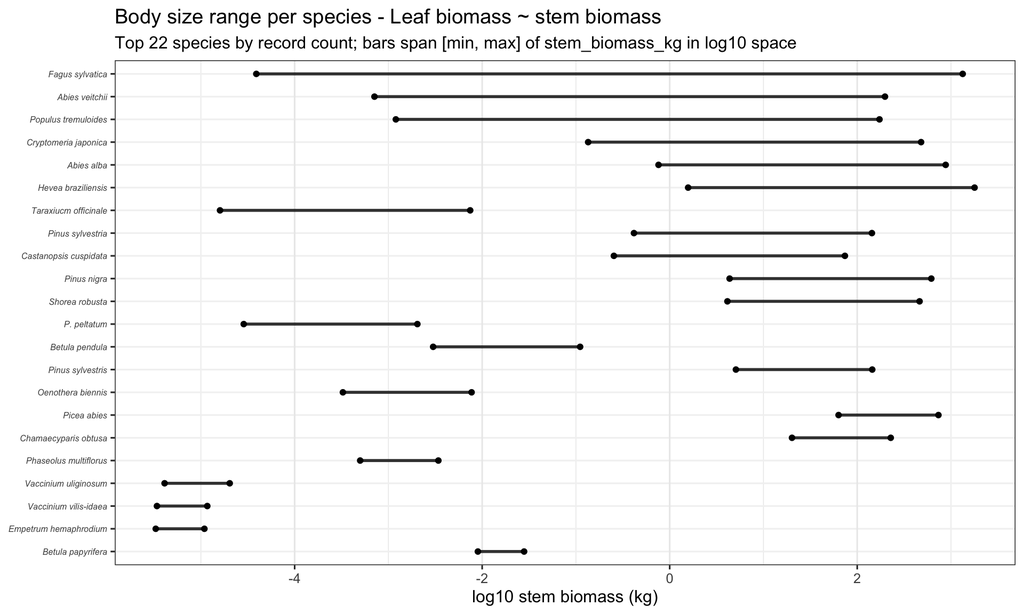

## Scaling slope vs. size range

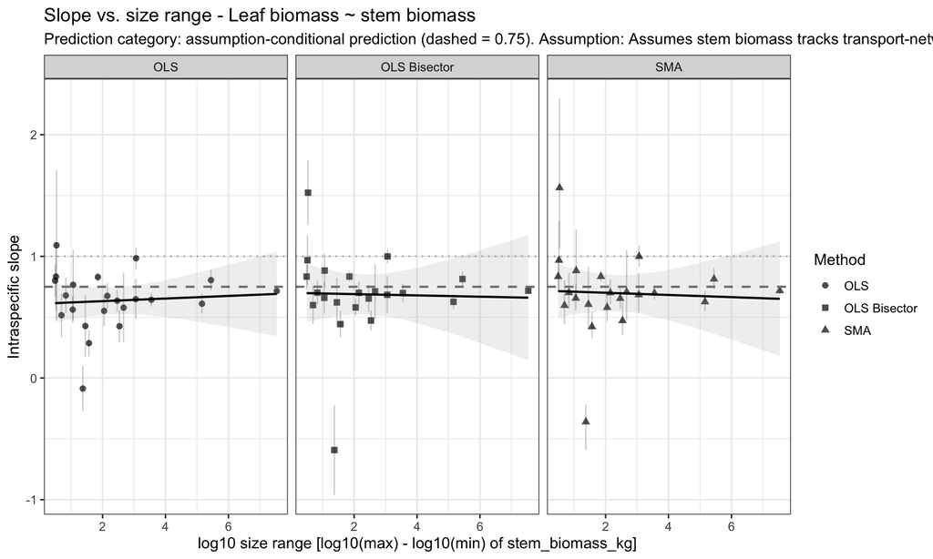

## Slope distributions

Leaf biomass ~ stem biomass: slope distribution summary statistics

| Method | N | Mean slope | Median slope | Mean 95% CI lo | Mean 95% CI hi |
| --- | --- | --- | --- | --- | --- |
| OLS | 22 | 0.635 | 0.646 | 0.527 | 0.743 |
| SMA | 22 | 0.698 | 0.699 | 0.551 | 0.844 |
| OLS Bisector | 22 | 0.688 | 0.700 | 0.528 | 0.848 |

## 2.4

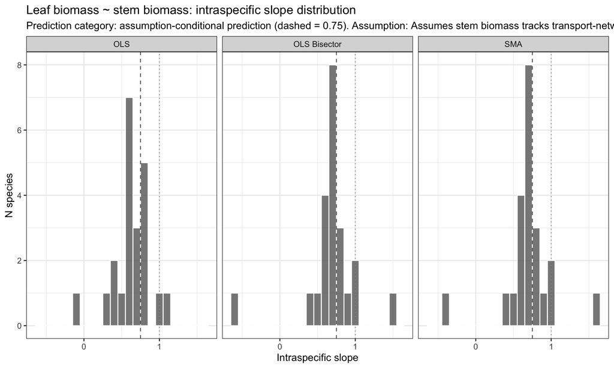

# 3 Leaf biomass ~ total biomass (leaf_biomass_kg ~ total_biomass_kg)

## 3.1 Summary stats

Leaf biomass ~ total biomass: summary statistics

| metric | value |
| --- | --- |
| Species qualifying (>=10 records) | 14.000 |
| Median OLS slope | 0.721 |
| Median SMA slope | 0.773 |
| Median OLS Bisector slope | 0.773 |

## 3.2 Per-species slopes table

Leaf biomass ~ total biomass: per-species OLS, SMA, and OLS Bisector slopes

| Species | Study | N | OLS slope | OLS 95% lo | OLS 95% hi | SMA slope | SMA 95% lo | SMA 95% hi | Bisector slope | Bis 95% lo | Bis 95% hi | R2 | log10 size range |
| --- | --- | --- | --- | --- | --- | --- | --- | --- | --- | --- | --- | --- | --- |
| *Cryptomeria japonica* | Cannell (1982). Page 151 | 50 | 0.757 | 0.680 | 0.834 | 0.802 | 0.729 | 0.883 | 0.803 | 0.726 | 0.879 | 0.890 | 3.168 |
| *Betula pendula* | Differences of Betula origins in ozone sensitivity based on open-field experiment over two growing seasons. Elina Oksanen and Matti Rousi. Can. J. For. Res. 31: 804-811. | 36 | 0.351 | 0.246 | 0.457 | 0.464 | 0.370 | 0.581 | 0.475 | 0.394 | 0.556 | 0.574 | 1.173 |
| *Oenothera biennis* | The Effect of Reproduction on Canopy Structure, Allocation and Growth in Oenothera Biennis. E. G. Reekie, J. Y. C. Reekie. Journal of Ecology, Vol. 79, No. 4. (Dec., 1991), pp. 1061-1071. | 18 | 1.379 | 1.005 | 1.754 | 1.550 | 1.220 | 1.969 | 1.545 | 1.212 | 1.879 | 0.792 | 0.331 |
| *Fagus sylvatica* | Cannell (1982). Page 31 | 17 | 0.771 | 0.757 | 0.785 | 0.771 | 0.757 | 0.786 | 0.771 | 0.763 | 0.780 | 0.999 | 7.072 |
| *Betula papyrifera* | Relative growth rate and biomass allocation of paper birch (Betula papyrifera) populations under different soil moisture and nutrient regimes. Jian R. Wang, C.D.B. Hawkins, and Tony Letchford. Can. J.… | 16 | 1.068 | 0.889 | 1.247 | 1.113 | 0.948 | 1.307 | 1.113 | 0.984 | 1.242 | 0.921 | 0.351 |
| *Chamaecyparis obtusa* | Cannell (1982). Page 135 | 15 | 0.504 | 0.381 | 0.628 | 0.545 | 0.435 | 0.682 | 0.546 | 0.444 | 0.647 | 0.858 | 0.914 |
| *Pinus nigra* | Cannell (1982). Page 202 | 13 | 0.625 | 0.531 | 0.720 | 0.641 | 0.554 | 0.743 | 0.642 | 0.573 | 0.711 | 0.951 | 1.567 |
| *Picea abies* | Cannell (1982). Page 29 | 12 | 0.795 | 0.491 | 1.098 | 0.904 | 0.650 | 1.257 | 0.905 | 0.779 | 1.030 | 0.773 | 1.068 |
| *Shorea robusta* | Cannell (1982). Page 79 | 12 | 0.583 | 0.452 | 0.713 | 0.611 | 0.495 | 0.756 | 0.612 | 0.540 | 0.684 | 0.908 | 1.952 |
| *Taraxiucm officinale* | Christopher Hogan, personal communication of unpublished data to Karl J. Niklas, Cornell University, Ithaca, New York, 2003. (Student of K. Niklas) | 12 | 1.083 | 0.902 | 1.263 | 1.112 | 0.946 | 1.308 | 1.112 | 0.983 | 1.242 | 0.947 | 1.473 |
| *Hevea braziliensis* | Cannell (1982). Page 192 | 11 | 0.685 | 0.511 | 0.860 | 0.724 | 0.570 | 0.919 | 0.724 | 0.561 | 0.887 | 0.897 | 2.895 |
| *Phaseolus multiflorus* | The Effect of Length of Day upon the Growth and Chemical Composition of the Tissues of certain Economic Plants. M.A.H. Tincker. Annals of Botany. Vol. 42, No 165 (January, 1928). Pp 101-140. | 10 | 0.668 | 0.324 | 1.012 | 0.790 | 0.518 | 1.206 | 0.792 | 0.572 | 1.013 | 0.715 | 0.745 |
| *Pinus sylvestria* | Cannell (1982). Page 244 | 10 | 0.541 | 0.365 | 0.717 | 0.583 | 0.432 | 0.785 | 0.583 | 0.518 | 0.649 | 0.862 | 2.103 |
| *Pinus sylvestris* | Cannell (1982). Page 63 | 10 | 0.761 | 0.645 | 0.876 | 0.774 | 0.667 | 0.898 | 0.774 | 0.710 | 0.838 | 0.967 | 1.324 |

## 3.3 Body size range per species

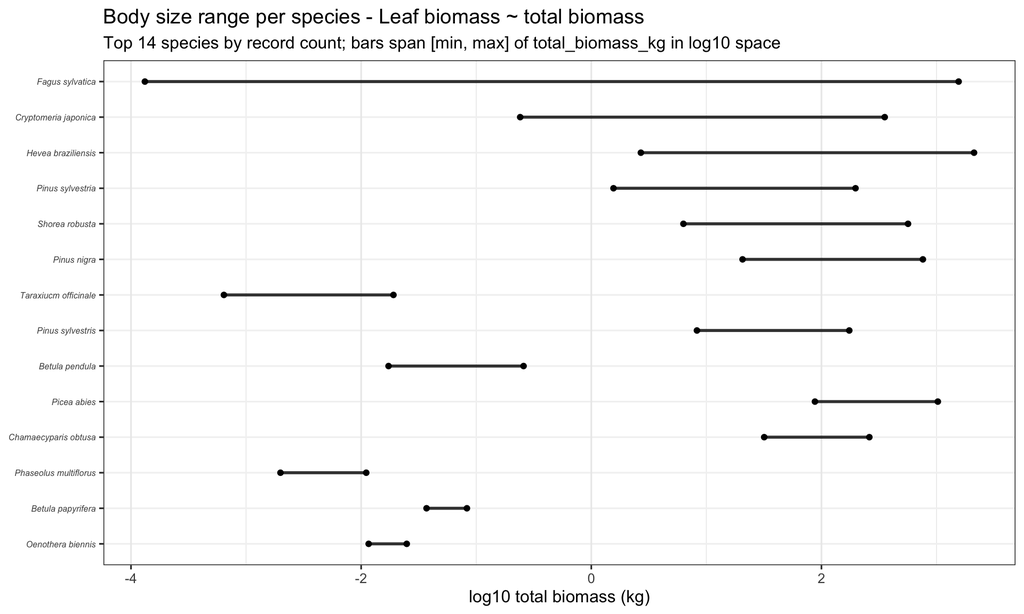

## Scaling slope vs. size range

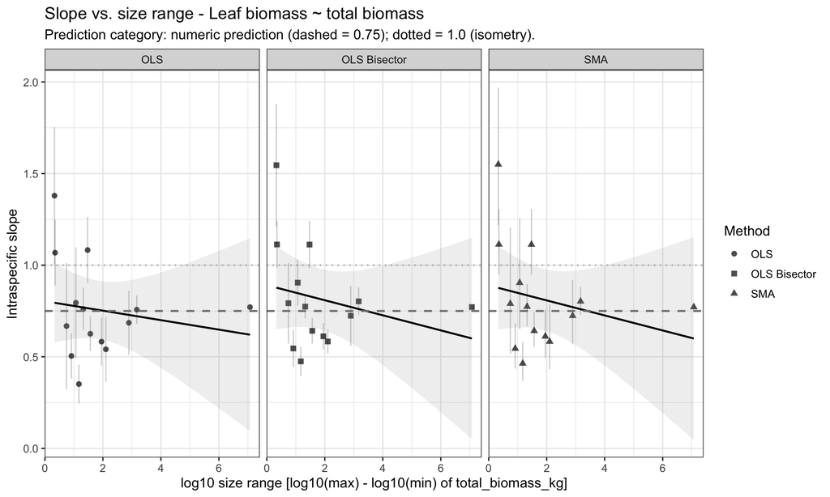

## Slope distributions

Leaf biomass ~ total biomass: slope distribution summary statistics

| Method | N | Mean slope | Median slope | Mean 95% CI lo | Mean 95% CI hi |
| --- | --- | --- | --- | --- | --- |
| OLS | 14 | 0.755 | 0.721 | 0.601 | 0.909 |
| SMA | 14 | 0.813 | 0.773 | 0.648 | 0.978 |
| OLS Bisector | 14 | 0.814 | 0.773 | 0.650 | 0.978 |

## 3.4

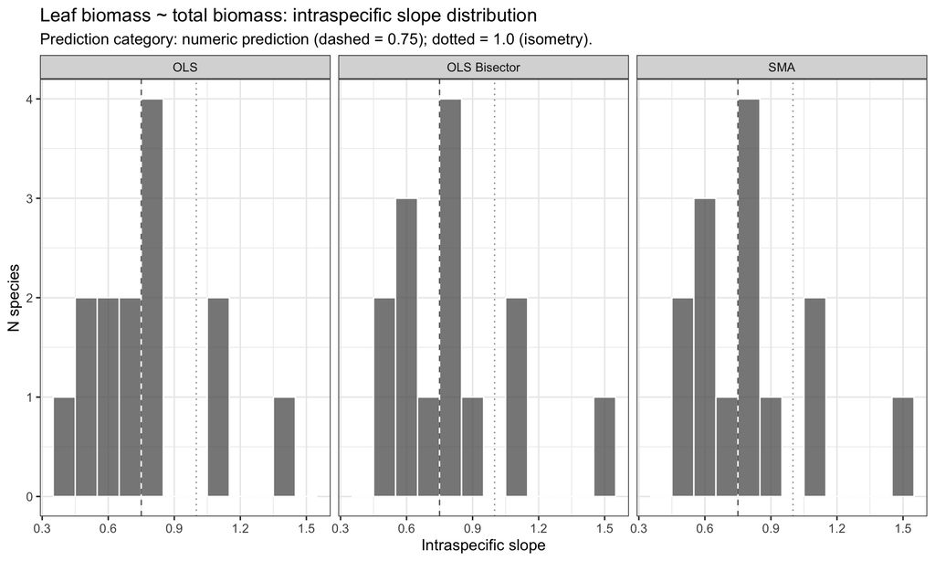

# 4 Leaf biomass ~ shoot biomass (leaf_biomass_kg ~ shoot_biomass_kg)

## 4.1 Summary stats

Leaf biomass ~ shoot biomass: summary statistics

| metric | value |
| --- | --- |
| Species qualifying (>=10 records) | 21.000 |
| Median OLS slope | 0.751 |
| Median SMA slope | 0.753 |
| Median OLS Bisector slope | 0.753 |

## 4.2 Per-species slopes table

Leaf biomass ~ shoot biomass: per-species OLS, SMA, and OLS Bisector slopes

| Species | Study | N | OLS slope | OLS 95% lo | OLS 95% hi | SMA slope | SMA 95% lo | SMA 95% hi | Bisector slope | Bis 95% lo | Bis 95% hi | R2 | log10 size range |
| --- | --- | --- | --- | --- | --- | --- | --- | --- | --- | --- | --- | --- | --- |
| *Cryptomeria japonica* | Cannell (1982). Page 151 | 96 | 0.704 | 0.653 | 0.756 | 0.748 | 0.698 | 0.802 | 0.749 | 0.678 | 0.819 | 0.886 | 3.389 |
| *Chamaecyparis obtusa* | Cannell (1982). Page 135 | 41 | 0.604 | 0.495 | 0.713 | 0.692 | 0.591 | 0.810 | 0.694 | 0.565 | 0.824 | 0.763 | 0.993 |
| *Betula pendula* | Differences of Betula origins in ozone sensitivity based on open-field experiment over two growing seasons. Elina Oksanen and Matti Rousi. Can. J. For. Res. 31: 804-811. | 36 | 0.441 | 0.312 | 0.571 | 0.577 | 0.462 | 0.720 | 0.587 | 0.486 | 0.688 | 0.586 | 1.048 |
| *Abies alba* | Cannell (1982). Page 57 | 19 | 0.987 | 0.902 | 1.072 | 1.000 | 0.919 | 1.089 | 1.000 | 0.947 | 1.054 | 0.972 | 3.062 |
| *Fagus sylvatica* | Cannell (1982). Page 31 | 19 | 0.751 | 0.724 | 0.778 | 0.753 | 0.726 | 0.781 | 0.753 | 0.733 | 0.773 | 0.995 | 7.206 |
| *Oenothera biennis* | The Effect of Reproduction on Canopy Structure, Allocation and Growth in Oenothera Biennis. E. G. Reekie, J. Y. C. Reekie. Journal of Ecology, Vol. 79, No. 4. (Dec., 1991), pp. 1061-1071. | 18 | 0.795 | 0.230 | 1.360 | 1.330 | 0.880 | 2.010 | 1.286 | 0.803 | 1.770 | 0.358 | 0.355 |
| *Pinus nigra* | Cannell (1982). Page 69 | 17 | 0.693 | 0.592 | 0.794 | 0.717 | 0.623 | 0.824 | 0.717 | 0.624 | 0.809 | 0.935 | 2.108 |
| *Vaccinium vilis-idaea* | Growth Responses of Four Sub-Arctic Dwarf Shrubs to Simulated Environmental Change. A. N. Parsons, J. M. Welker, P. A. Wookey, M. C. Press, T. V. Callaghan, J. A. Lee. Journal of Ecology, Vol. 82, No.… | 17 | 1.083 | 1.012 | 1.154 | 1.091 | 1.022 | 1.164 | 1.091 | 1.048 | 1.133 | 0.986 | 0.703 |
| *Betula papyrifera* | Relative growth rate and biomass allocation of paper birch (Betula papyrifera) populations under different soil moisture and nutrient regimes. Jian R. Wang, C.D.B. Hawkins, and Tony Letchford. Can. J.… | 16 | 0.915 | 0.839 | 0.992 | 0.925 | 0.852 | 1.005 | 0.925 | 0.868 | 0.982 | 0.979 | 0.434 |
| *Empetrum hemaphrodium* | Growth Responses of Four Sub-Arctic Dwarf Shrubs to Simulated Environmental Change. A. N. Parsons, J. M. Welker, P. A. Wookey, M. C. Press, T. V. Callaghan, J. A. Lee. Journal of Ecology, Vol. 82, No.… | 16 | 1.014 | 0.891 | 1.137 | 1.036 | 0.921 | 1.167 | 1.036 | 0.950 | 1.123 | 0.957 | 0.446 |
| *Castanopsis cuspidata* | Cannell (1982). Page 102 | 15 | 0.665 | 0.582 | 0.749 | 0.680 | 0.602 | 0.768 | 0.680 | 0.577 | 0.783 | 0.958 | 2.415 |
| *Pinus sylvestris* | Cannell (1982). Page 63 | 15 | 0.489 | 0.232 | 0.745 | 0.650 | 0.442 | 0.955 | 0.660 | 0.463 | 0.857 | 0.566 | 1.419 |
| *Populus tremuloides* | Cannell (1982). Page 36 | 15 | 0.663 | 0.578 | 0.749 | 0.679 | 0.598 | 0.770 | 0.679 | 0.619 | 0.738 | 0.956 | 4.847 |
| *Vaccinium uliginosum* | Growth Responses of Four Sub-Arctic Dwarf Shrubs to Simulated Environmental Change. A. N. Parsons, J. M. Welker, P. A. Wookey, M. C. Press, T. V. Callaghan, J. A. Lee. Journal of Ecology, Vol. 82, No.… | 15 | 0.875 | 0.782 | 0.969 | 0.889 | 0.801 | 0.987 | 0.889 | 0.796 | 0.982 | 0.969 | 0.419 |
| *Picea abies* | Cannell (1982). Page 29 | 13 | 0.792 | 0.512 | 1.071 | 0.897 | 0.660 | 1.219 | 0.898 | 0.764 | 1.032 | 0.779 | 1.054 |
| *Pinus sylvestria* | Cannell (1982). Page 243 | 13 | 0.485 | 0.345 | 0.625 | 0.529 | 0.407 | 0.687 | 0.530 | 0.446 | 0.614 | 0.841 | 2.254 |
| *Abies veitchii* | Cannell (1982). Page 129 | 12 | 0.843 | 0.765 | 0.922 | 0.851 | 0.776 | 0.933 | 0.851 | 0.796 | 0.906 | 0.983 | 5.229 |
| *Shorea robusta* | Cannell (1982). Page 79 | 12 | 0.571 | 0.446 | 0.697 | 0.599 | 0.486 | 0.738 | 0.599 | 0.531 | 0.667 | 0.911 | 1.986 |
| *Hevea braziliensis* | Cannell (1982). Page 192 | 11 | 0.665 | 0.502 | 0.829 | 0.700 | 0.555 | 0.882 | 0.700 | 0.551 | 0.849 | 0.904 | 3.001 |
| *Taraxiucm officinale* | Christopher Hogan, personal communication of unpublished data to Karl J. Niklas, Cornell University, Ithaca, New York, 2003. (Student of K. Niklas) | 11 | 0.964 | 0.836 | 1.092 | 0.979 | 0.859 | 1.116 | 0.979 | 0.866 | 1.092 | 0.970 | 1.768 |
| *Phaseolus multiflorus* | The Effect of Length of Day upon the Growth and Chemical Composition of the Tissues of certain Economic Plants. M.A.H. Tincker. Annals of Botany. Vol. 42, No 165 (January, 1928). Pp 101-140. | 10 | 0.854 | 0.764 | 0.943 | 0.861 | 0.776 | 0.955 | 0.861 | 0.798 | 0.924 | 0.984 | 0.678 |

## 4.3 Body size range per species

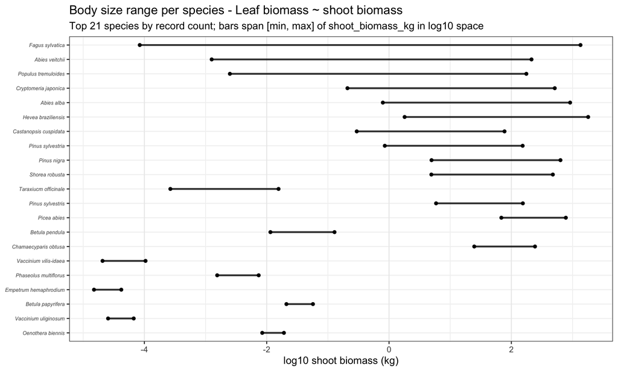

## Scaling slope vs. size range

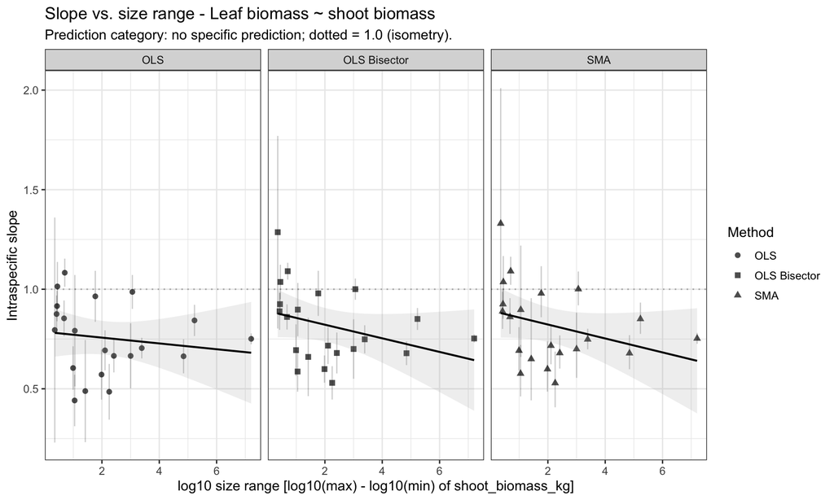

## Slope distributions

Leaf biomass ~ shoot biomass: slope distribution summary statistics

| Method | N | Mean slope | Median slope | Mean 95% CI lo | Mean 95% CI hi |
| --- | --- | --- | --- | --- | --- |
| OLS | 21 | 0.755 | 0.751 | 0.672 | 0.838 |
| SMA | 21 | 0.818 | 0.753 | 0.729 | 0.908 |
| OLS Bisector | 21 | 0.817 | 0.753 | 0.731 | 0.904 |

## 4.4

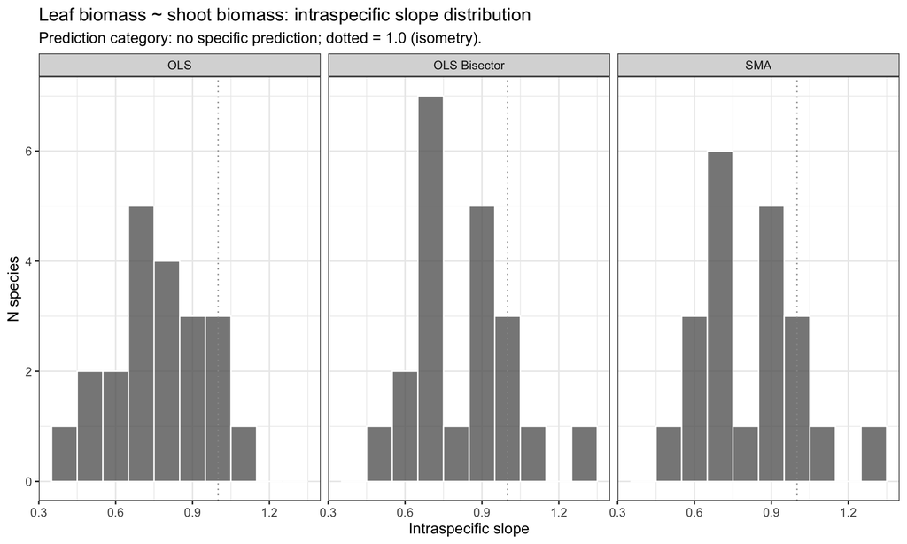

# 5 Leaf biomass ~ root biomass (leaf_biomass_kg ~ root_biomass_kg)

## 5.1 Summary stats

Leaf biomass ~ root biomass: summary statistics

| metric | value |
| --- | --- |
| Species qualifying (>=10 records) | 14.000 |
| Median OLS slope | 0.680 |
| Median SMA slope | 0.723 |
| Median OLS Bisector slope | 0.723 |

## 5.2 Per-species slopes table

Leaf biomass ~ root biomass: per-species OLS, SMA, and OLS Bisector slopes

| Species | Study | N | OLS slope | OLS 95% lo | OLS 95% hi | SMA slope | SMA 95% lo | SMA 95% hi | Bisector slope | Bis 95% lo | Bis 95% hi | R2 | log10 size range |
| --- | --- | --- | --- | --- | --- | --- | --- | --- | --- | --- | --- | --- | --- |
| *Cryptomeria japonica* | Cannell (1982). Page 151 | 50 | 0.701 | 0.624 | 0.778 | 0.750 | 0.677 | 0.831 | 0.750 | 0.668 | 0.833 | 0.875 | 3.469 |
| *Betula pendula* | Cannell (1982). Page 23 | 37 | 0.438 | 0.332 | 0.544 | 0.536 | 0.440 | 0.653 | 0.542 | 0.356 | 0.728 | 0.667 | 3.045 |
| *Oenothera biennis* | The Effect of Reproduction on Canopy Structure, Allocation and Growth in Oenothera Biennis. E. G. Reekie, J. Y. C. Reekie. Journal of Ecology, Vol. 79, No. 4. (Dec., 1991), pp. 1061-1071. | 18 | 0.384 | 0.113 | 0.655 | 0.640 | 0.424 | 0.966 | 0.672 | 0.438 | 0.906 | 0.361 | 0.944 |
| *Fagus sylvatica* | Cannell (1982). Page 31 | 17 | 0.844 | 0.822 | 0.866 | 0.845 | 0.823 | 0.867 | 0.845 | 0.826 | 0.863 | 0.998 | 6.638 |
| *Betula papyrifera* | Relative growth rate and biomass allocation of paper birch (Betula papyrifera) populations under different soil moisture and nutrient regimes. Jian R. Wang, C.D.B. Hawkins, and Tony Letchford. Can. J.… | 16 | 1.061 | 0.508 | 1.614 | 1.434 | 0.984 | 2.090 | 1.412 | 1.076 | 1.749 | 0.547 | 0.323 |
| *Chamaecyparis obtusa* | Cannell (1982). Page 135 | 15 | 0.500 | 0.370 | 0.630 | 0.545 | 0.430 | 0.691 | 0.546 | 0.440 | 0.653 | 0.841 | 0.917 |
| *Taraxiucm officinale* | Christopher Hogan, personal communication of unpublished data to Karl J. Niklas, Cornell University, Ithaca, New York, 2003. (Student of K. Niklas) | 15 | 1.104 | 0.773 | 1.435 | 1.235 | 0.947 | 1.609 | 1.233 | 0.979 | 1.487 | 0.800 | 1.623 |
| *Pinus nigra* | Cannell (1982). Page 202 | 13 | 0.675 | 0.564 | 0.786 | 0.695 | 0.593 | 0.815 | 0.696 | 0.613 | 0.778 | 0.942 | 1.569 |
| *Picea abies* | Cannell (1982). Page 29 | 12 | 0.696 | 0.382 | 1.010 | 0.826 | 0.570 | 1.197 | 0.828 | 0.703 | 0.953 | 0.709 | 1.155 |
| *Shorea robusta* | Cannell (1982). Page 79 | 12 | 0.628 | 0.467 | 0.788 | 0.668 | 0.526 | 0.847 | 0.668 | 0.575 | 0.761 | 0.884 | 1.804 |
| *Hevea braziliensis* | Cannell (1982). Page 192 | 11 | 0.767 | 0.541 | 0.993 | 0.823 | 0.628 | 1.080 | 0.824 | 0.605 | 1.043 | 0.868 | 2.549 |
| *Phaseolus multiflorus* | The Effect of Length of Day upon the Growth and Chemical Composition of the Tissues of certain Economic Plants. M.A.H. Tincker. Annals of Botany. Vol. 42, No 165 (January, 1928). Pp 101-140. | 10 | 0.160 | -0.170 | 0.490 | 0.435 | 0.216 | 0.875 | 0.564 | 0.237 | 0.892 | 0.135 | 1.268 |
| *Pinus sylvestria* | Cannell (1982). Page 244 | 10 | 0.616 | 0.405 | 0.827 | 0.668 | 0.490 | 0.912 | 0.669 | 0.593 | 0.746 | 0.850 | 1.803 |
| *Pinus sylvestris* | Cannell (1982). Page 63 | 10 | 0.686 | 0.397 | 0.974 | 0.771 | 0.535 | 1.112 | 0.773 | 0.648 | 0.897 | 0.790 | 1.250 |

## 5.3 Body size range per species

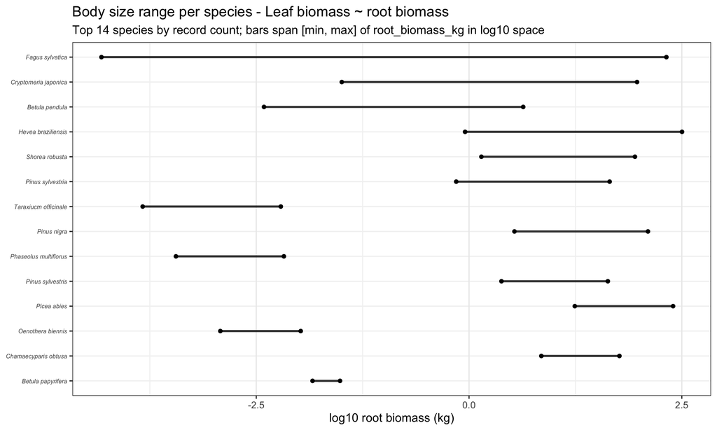

## Scaling slope vs. size range

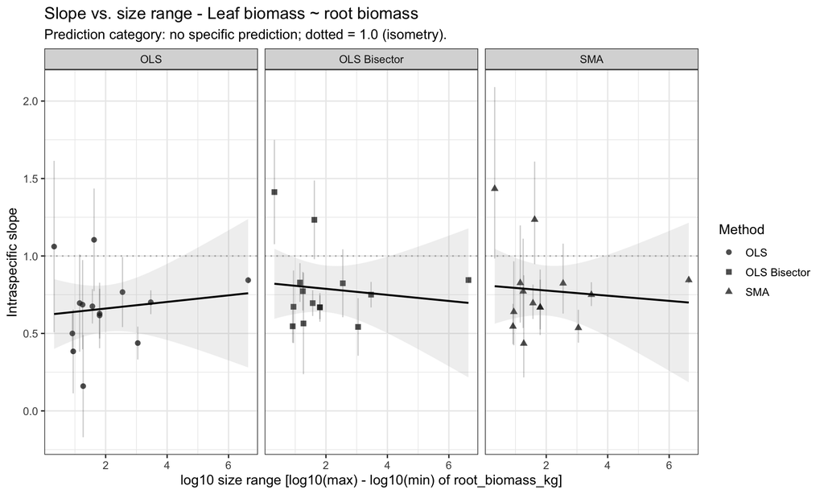

## Slope distributions

Leaf biomass ~ root biomass: slope distribution summary statistics

| Method | N | Mean slope | Median slope | Mean 95% CI lo | Mean 95% CI hi |
| --- | --- | --- | --- | --- | --- |
| OLS | 14 | 0.661 | 0.680 | 0.517 | 0.806 |
| SMA | 14 | 0.777 | 0.723 | 0.622 | 0.931 |
| OLS Bisector | 14 | 0.787 | 0.723 | 0.643 | 0.932 |

## 5.4

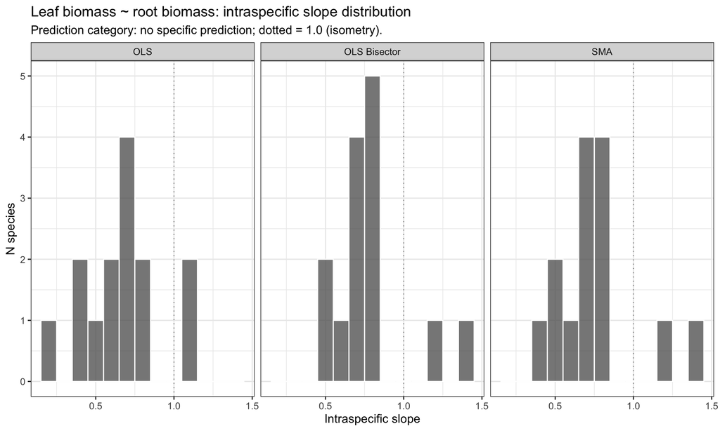

# 6 Leaf biomass ~ height (leaf_biomass_kg ~ height_m)

## 6.1 Summary stats

Leaf biomass ~ height: summary statistics

| metric | value |
| --- | --- |
| Species qualifying (>=10 records) | 15.000 |
| Median OLS slope | 1.721 |
| Median SMA slope | 2.040 |
| Median OLS Bisector slope | 1.992 |

## 6.2 Per-species slopes table

Leaf biomass ~ height: per-species OLS, SMA, and OLS Bisector slopes

| Species | Study | N | OLS slope | OLS 95% lo | OLS 95% hi | SMA slope | SMA 95% lo | SMA 95% hi | Bisector slope | Bis 95% lo | Bis 95% hi | R2 | log10 size range |
| --- | --- | --- | --- | --- | --- | --- | --- | --- | --- | --- | --- | --- | --- |
| *Cryptomeria japonica* | Cannell (1982). Page 152 | 89 | 1.789 | 1.500 | 2.079 | 2.246 | 1.975 | 2.553 | 2.208 | 1.660 | 2.756 | 0.635 | 0.880 |
| *Chamaecyparis obtusa* | Cannell (1982). Page 135 | 41 | 1.251 | 0.688 | 1.813 | 2.141 | 1.651 | 2.776 | 1.966 | 1.694 | 2.238 | 0.341 | 0.434 |
| *Betula pendula* | Cannell (1982). Page 23 | 37 | 1.456 | 1.137 | 1.775 | 1.728 | 1.438 | 2.077 | 1.716 | 1.539 | 1.892 | 0.710 | 1.089 |
| *Fagus sylvatica* | Cannell (1982). Page 31 | 19 | 2.553 | 1.878 | 3.228 | 2.874 | 2.277 | 3.627 | 2.858 | 2.295 | 3.421 | 0.789 | 0.595 |
| *Abies alba* | Cannell (1982). Page 57 | 17 | 2.375 | 1.768 | 2.983 | 2.619 | 2.081 | 3.297 | 2.610 | 1.875 | 3.345 | 0.822 | 0.499 |
| *Vaccinium vilis-idaea* | Growth Responses of Four Sub-Arctic Dwarf Shrubs to Simulated Environmental Change. A. N. Parsons, J. M. Welker, P. A. Wookey, M. C. Press, T. V. Callaghan, J. A. Lee. Journal of Ecology, Vol. 82, No.… | 17 | 1.721 | 0.662 | 2.780 | 2.582 | 1.731 | 3.850 | 2.436 | 1.899 | 2.973 | 0.444 | 0.313 |
| *Empetrum hemaphrodium* | Growth Responses of Four Sub-Arctic Dwarf Shrubs to Simulated Environmental Change. A. N. Parsons, J. M. Welker, P. A. Wookey, M. C. Press, T. V. Callaghan, J. A. Lee. Journal of Ecology, Vol. 82, No.… | 16 | 0.474 | -0.220 | 1.168 | 1.300 | 0.780 | 2.168 | 1.185 | 0.826 | 1.545 | 0.133 | 0.300 |
| *Pinus nigra* | Cannell (1982). Page 69 | 16 | 1.920 | 1.523 | 2.316 | 2.040 | 1.682 | 2.475 | 2.038 | 1.718 | 2.358 | 0.885 | 0.742 |
| *Castanopsis cuspidata* | Cannell (1982). Page 102 | 15 | 1.761 | 1.353 | 2.169 | 1.888 | 1.524 | 2.340 | 1.886 | 1.322 | 2.449 | 0.870 | 1.125 |
| *Vaccinium uliginosum* | Growth Responses of Four Sub-Arctic Dwarf Shrubs to Simulated Environmental Change. A. N. Parsons, J. M. Welker, P. A. Wookey, M. C. Press, T. V. Callaghan, J. A. Lee. Journal of Ecology, Vol. 82, No.… | 15 | 0.480 | 0.131 | 0.829 | 0.755 | 0.483 | 1.180 | 0.775 | 0.496 | 1.054 | 0.405 | 0.620 |
| *Populus tremuloides* | Cannell (1982). Page 36 | 14 | 1.929 | 1.614 | 2.243 | 1.992 | 1.703 | 2.331 | 1.992 | 1.787 | 2.196 | 0.937 | 1.786 |
| *Picea abies* | Cannell (1982). Page 29 | 13 | 1.714 | -0.031 | 3.459 | 3.139 | 1.847 | 5.337 | 2.738 | 1.613 | 3.863 | 0.298 | 0.286 |
| *Pinus sylvestria* | Cannell (1982). Page 243 | 13 | 0.885 | 0.512 | 1.257 | 1.048 | 0.739 | 1.484 | 1.047 | 0.787 | 1.307 | 0.713 | 1.071 |
| *Abies veitchii* | Cannell (1982). Page 129 | 12 | 2.199 | 1.304 | 3.094 | 2.539 | 1.797 | 3.588 | 2.520 | 1.473 | 3.568 | 0.750 | 1.513 |
| *Shorea robusta* | Cannell (1982). Page 79 | 12 | 1.492 | 0.855 | 2.129 | 1.745 | 1.220 | 2.495 | 1.734 | 1.317 | 2.151 | 0.731 | 0.654 |

## 6.3 Body size range per species

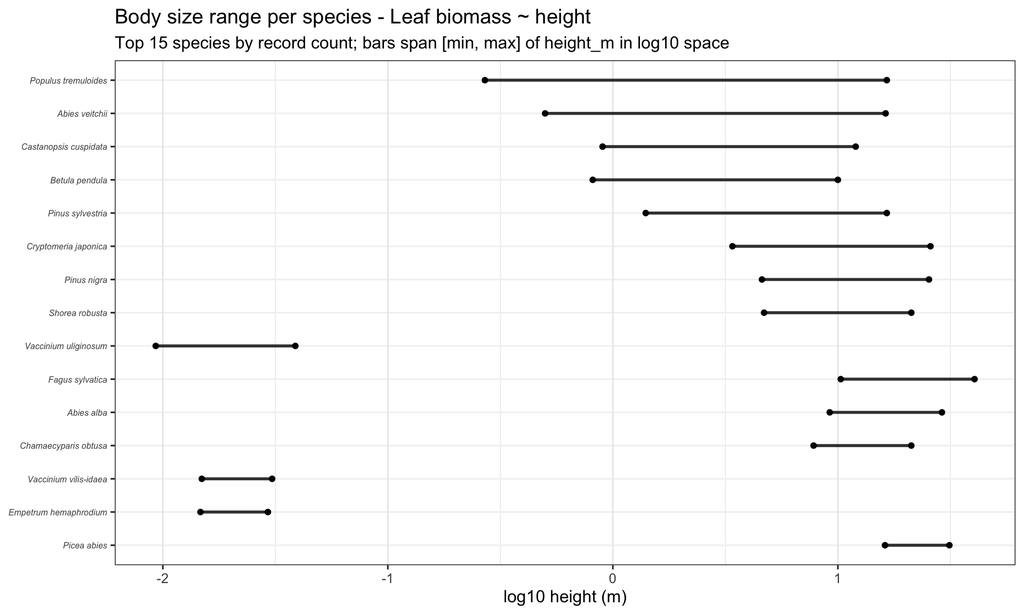

## Scaling slope vs. size range

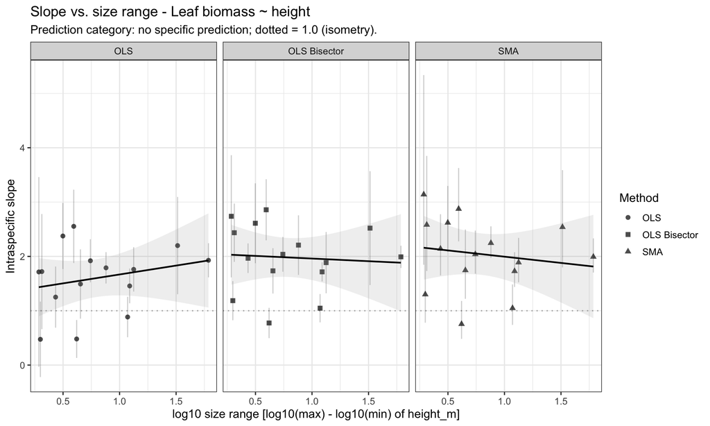

## Slope distributions

Leaf biomass ~ height: slope distribution summary statistics

| Method | N | Mean slope | Median slope | Mean 95% CI lo | Mean 95% CI hi |
| --- | --- | --- | --- | --- | --- |
| OLS | 15 | 1.600 | 1.721 | 1.257 | 1.942 |
| SMA | 15 | 2.042 | 2.040 | 1.673 | 2.412 |
| OLS Bisector | 15 | 1.981 | 1.992 | 1.637 | 2.324 |

## 6.4

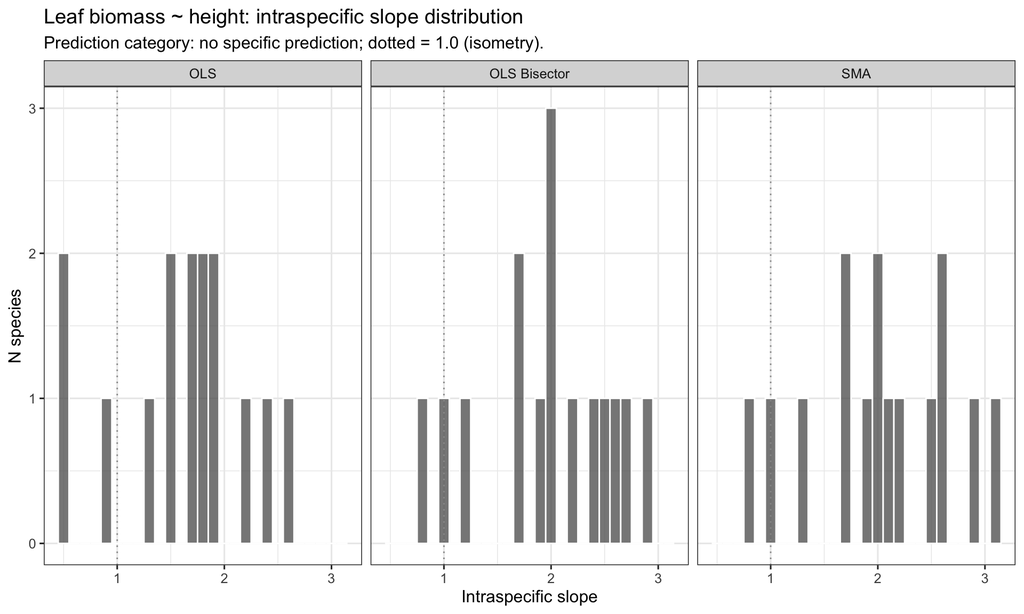

# 7 Leaf growth ~ total biomass (leaf_growth_kgyr ~ total_biomass_kg)

## 7.1 Summary stats

Leaf growth ~ total biomass: summary statistics

| metric | value |
| --- | --- |
| Species qualifying (>=10 records) | 7.000 |
| Median OLS slope | 0.699 |
| Median SMA slope | 0.818 |
| Median OLS Bisector slope | 0.820 |

## 7.2 Per-species slopes table

Leaf growth ~ total biomass: per-species OLS, SMA, and OLS Bisector slopes

| Species | Study | N | OLS slope | OLS 95% lo | OLS 95% hi | SMA slope | SMA 95% lo | SMA 95% hi | Bisector slope | Bis 95% lo | Bis 95% hi | R2 | log10 size range |
| --- | --- | --- | --- | --- | --- | --- | --- | --- | --- | --- | --- | --- | --- |
| *Cryptomeria japonica* | Cannell (1982). Page 152 | 20 | 0.757 | 0.684 | 0.829 | 0.770 | 0.702 | 0.846 | 0.771 | 0.734 | 0.807 | 0.964 | 3.168 |
| *Oenothera biennis* | The Effect of Reproduction on Canopy Structure, Allocation and Growth in Oenothera Biennis. E. G. Reekie, J. Y. C. Reekie. Journal of Ecology, Vol. 79, No. 4. (Dec., 1991), pp. 1061-1071. | 18 | 0.671 | -0.109 | 1.452 | 1.619 | 1.017 | 2.578 | 1.415 | 0.928 | 1.902 | 0.172 | 0.331 |
| *Fagus sylvatica* | Cannell (1982). Page 31 | 17 | 0.699 | 0.678 | 0.720 | 0.700 | 0.679 | 0.721 | 0.700 | 0.686 | 0.714 | 0.997 | 7.081 |
| *Betula papyrifera* | Relative growth rate and biomass allocation of paper birch (Betula papyrifera) populations under different soil moisture and nutrient regimes. Jian R. Wang, C.D.B. Hawkins, and Tony Letchford. Can. J.… | 16 | 1.068 | 0.889 | 1.247 | 1.113 | 0.948 | 1.307 | 1.113 | 0.984 | 1.242 | 0.921 | 0.351 |
| *Chamaecyparis obtusa* | Cannell (1982). Page 135 | 15 | 0.514 | 0.419 | 0.610 | 0.538 | 0.451 | 0.642 | 0.539 | 0.440 | 0.637 | 0.912 | 0.914 |
| *Taraxiucm officinale* | Christopher Hogan, personal communication of unpublished data to Karl J. Niklas, Cornell University, Ithaca, New York, 2003. (Student of K. Niklas) | 12 | 1.083 | 0.902 | 1.263 | 1.112 | 0.946 | 1.308 | 1.112 | 0.983 | 1.242 | 0.947 | 1.473 |
| *Phaseolus multiflorus* | The Effect of Length of Day upon the Growth and Chemical Composition of the Tissues of certain Economic Plants. M.A.H. Tincker. Annals of Botany. Vol. 42, No 165 (January, 1928). Pp 101-140. | 10 | 0.687 | 0.326 | 1.049 | 0.818 | 0.533 | 1.256 | 0.820 | 0.581 | 1.060 | 0.706 | 0.745 |

## 7.3 Body size range per species

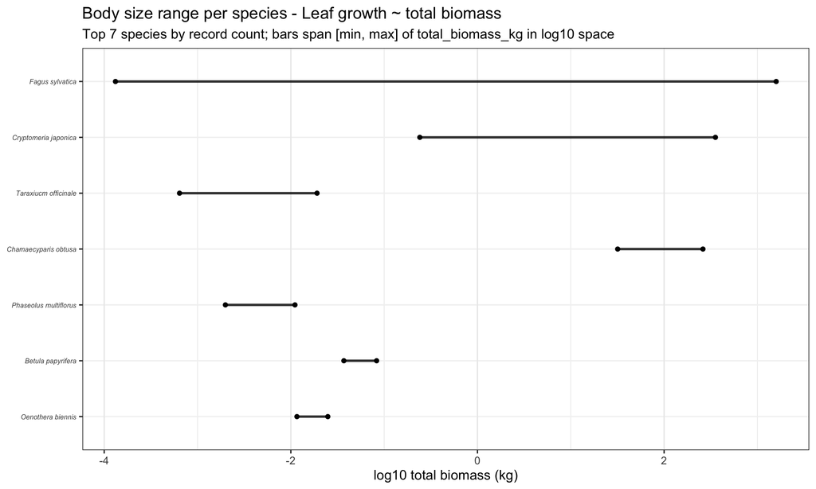

## Scaling slope vs. size range

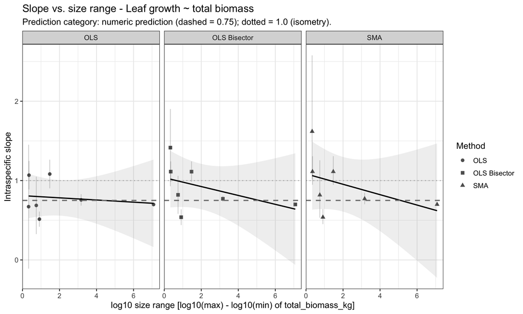

## Slope distributions

Leaf growth ~ total biomass: slope distribution summary statistics

| Method | N | Mean slope | Median slope | Mean 95% CI lo | Mean 95% CI hi |
| --- | --- | --- | --- | --- | --- |
| OLS | 7 | 0.783 | 0.699 | 0.585 | 0.980 |
| SMA | 7 | 0.953 | 0.818 | 0.619 | 1.287 |
| OLS Bisector | 7 | 0.924 | 0.820 | 0.645 | 1.203 |

## 7.4

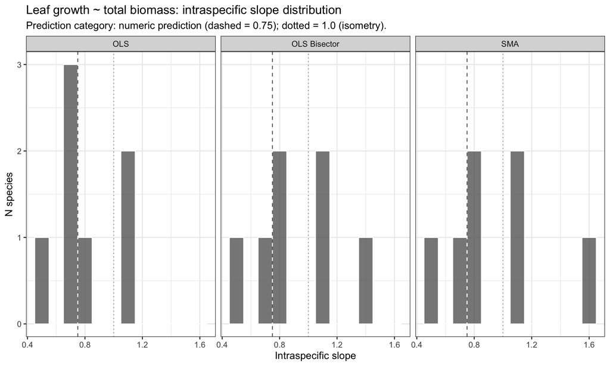

# 8 Total growth (dM/dt) ~ stem biomass (total_growth_kgyr ~ stem_biomass_kg)

## 8.1 Summary stats

Total growth (dM/dt) ~ stem biomass: summary statistics

| metric | value |
| --- | --- |
| Species qualifying (>=10 records) | 7.000 |
| Median OLS slope | 0.633 |
| Median SMA slope | 0.656 |
| Median OLS Bisector slope | 0.656 |

## 8.2 Per-species slopes table

Total growth (dM/dt) ~ stem biomass: per-species OLS, SMA, and OLS Bisector slopes

| Species | Study | N | OLS slope | OLS 95% lo | OLS 95% hi | SMA slope | SMA 95% lo | SMA 95% hi | Bisector slope | Bis 95% lo | Bis 95% hi | R2 | log10 size range |
| --- | --- | --- | --- | --- | --- | --- | --- | --- | --- | --- | --- | --- | --- |
| *Cryptomeria japonica* | Cannell (1982). Page 152 | 55 | 0.633 | 0.565 | 0.701 | 0.679 | 0.615 | 0.751 | 0.680 | 0.612 | 0.748 | 0.868 | 3.551 |
| *Oenothera biennis* | The Effect of Reproduction on Canopy Structure, Allocation and Growth in Oenothera Biennis. E. G. Reekie, J. Y. C. Reekie. Journal of Ecology, Vol. 79, No. 4. (Dec., 1991), pp. 1061-1071. | 18 | -0.117 | -0.247 | 0.013 | -0.271 | -0.431 | -0.171 | -0.353 | -0.538 | -0.168 | 0.186 | 1.373 |
| *Betula papyrifera* | Relative growth rate and biomass allocation of paper birch (Betula papyrifera) populations under different soil moisture and nutrient regimes. Jian R. Wang, C.D.B. Hawkins, and Tony Letchford. Can. J.… | 16 | 0.741 | 0.681 | 0.802 | 0.749 | 0.691 | 0.812 | 0.749 | 0.703 | 0.795 | 0.980 | 0.493 |
| *Chamaecyparis obtusa* | Cannell (1982). Page 135 | 15 | 0.496 | 0.371 | 0.622 | 0.539 | 0.428 | 0.679 | 0.540 | 0.448 | 0.632 | 0.848 | 0.969 |
| *Fagus sylvatica* | Cannell (1982). Page 66 | 13 | 0.654 | 0.618 | 0.689 | 0.656 | 0.622 | 0.692 | 0.656 | 0.626 | 0.685 | 0.993 | 7.543 |
| *Taraxiucm officinale* | Christopher Hogan, personal communication of unpublished data to Karl J. Niklas, Cornell University, Ithaca, New York, 2003. (Student of K. Niklas) | 11 | 0.554 | 0.347 | 0.761 | 0.618 | 0.445 | 0.858 | 0.620 | 0.466 | 0.774 | 0.803 | 2.668 |
| *Phaseolus multiflorus* | The Effect of Length of Day upon the Growth and Chemical Composition of the Tissues of certain Economic Plants. M.A.H. Tincker. Annals of Botany. Vol. 42, No 165 (January, 1928). Pp 101-140. | 10 | 0.695 | 0.222 | 1.169 | 0.906 | 0.549 | 1.496 | 0.909 | 0.644 | 1.174 | 0.589 | 0.834 |

## 8.3 Body size range per species

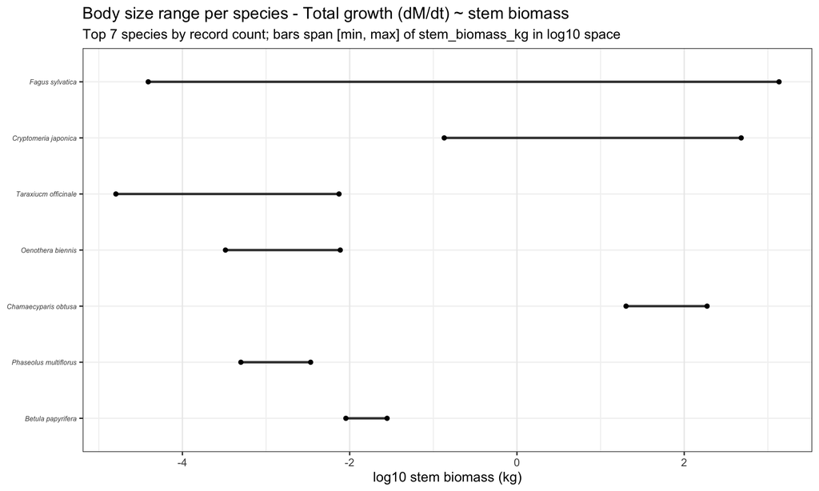

## Scaling slope vs. size range

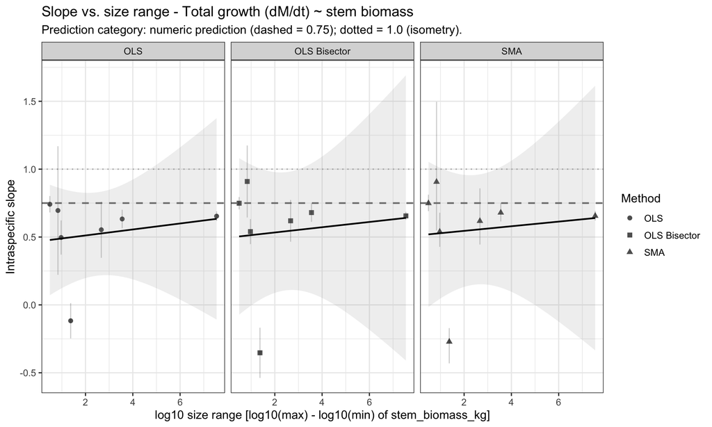

## Slope distributions

Total growth (dM/dt) ~ stem biomass: slope distribution summary statistics

| Method | N | Mean slope | Median slope | Mean 95% CI lo | Mean 95% CI hi |
| --- | --- | --- | --- | --- | --- |
| OLS | 7 | 0.522 | 0.633 | 0.251 | 0.794 |
| SMA | 7 | 0.554 | 0.656 | 0.201 | 0.907 |
| OLS Bisector | 7 | 0.543 | 0.656 | 0.162 | 0.924 |

## 8.4

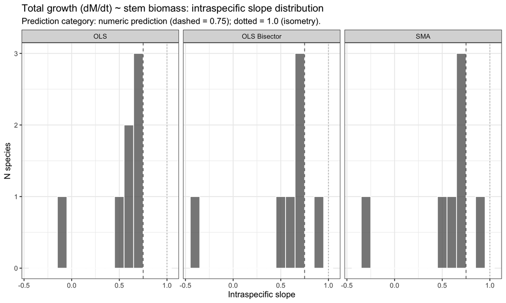

# 9 Total growth (dM/dt) ~ shoot biomass (aboveground proxy) (total_growth_kgyr ~ shoot_biomass_kg)

## 9.1 Summary stats

Total growth (dM/dt) ~ shoot biomass (aboveground proxy): summary statistics

| metric | value |
| --- | --- |
| Species qualifying (>=10 records) | 15.000 |
| Median OLS slope | 0.745 |
| Median SMA slope | 0.762 |
| Median OLS Bisector slope | 0.763 |

## 9.2 Per-species slopes table

Total growth (dM/dt) ~ shoot biomass (aboveground proxy): per-species OLS, SMA, and OLS Bisector slopes

| Species | Study | N | OLS slope | OLS 95% lo | OLS 95% hi | SMA slope | SMA 95% lo | SMA 95% hi | Bisector slope | Bis 95% lo | Bis 95% hi | R2 | log10 size range |
| --- | --- | --- | --- | --- | --- | --- | --- | --- | --- | --- | --- | --- | --- |
| *Triticum aestivum* | Interactive Effects of (2-Chloroethyl)-Trimethyllammonium Chloride and Phytohormones on growth of wheat seedlings. F. Begum and M.I. Khan. Pakistan Journal of Botany, Vol 4, No. 1. (June 1972) Pp: 35-… | 86 | 0.693 | 0.661 | 0.724 | 0.707 | 0.677 | 0.740 | 0.708 | 0.683 | 0.732 | 0.958 | 3.743 |
| *Cryptomeria japonica* | Cannell (1982). Page 152 | 55 | 0.693 | 0.629 | 0.756 | 0.730 | 0.669 | 0.797 | 0.731 | 0.673 | 0.789 | 0.900 | 3.389 |
| *Pisum sativum* | Studies in Growth IV. Correlations in Development. W.H. Pearsall. Annals of Botany, Vol 37 No. 146 (April 1923). Pp. (261-275). | 51 | 0.212 | 0.134 | 0.289 | 0.344 | 0.275 | 0.430 | 0.375 | 0.294 | 0.455 | 0.380 | 2.701 |
| *Soja max* | Influence of Ammonium Sulfate on Plant Growth in Nutrient Solutions and its Effect on Hydrogen ion Concentration and Iron Availability. Linus H. Jones and John W. Shive. Annals of Botany, Vol 37 No. 1… | 44 | 0.987 | 0.967 | 1.007 | 0.989 | 0.969 | 1.010 | 0.989 | 0.970 | 1.008 | 0.996 | 0.484 |
| *Vicia faba* | Response of Seeds and Seedlings to Treatment with Indolylacetic Acid. Y. Hwang and H.L. Pearse. Annals of Botany, N.S. Vol 4, No 13 (January 1940) Pp. 31-37. | 24 | 0.758 | 0.670 | 0.846 | 0.784 | 0.701 | 0.876 | 0.784 | 0.702 | 0.865 | 0.936 | 1.342 |
| *Acacia mangium* | The requirement of iron for nodulation and growth of (Acacia mangium). D. Lesueur and H.G. Diem. Can. J. For. Res. 27: 686-692. | 22 | 0.976 | 0.950 | 1.003 | 0.978 | 0.952 | 1.005 | 0.978 | 0.957 | 0.999 | 0.997 | 1.316 |
| *Oenothera biennis* | The Effect of Reproduction on Canopy Structure, Allocation and Growth in Oenothera Biennis. E. G. Reekie, J. Y. C. Reekie. Journal of Ecology, Vol. 79, No. 4. (Dec., 1991), pp. 1061-1071. | 18 | -0.182 | -0.704 | 0.339 | -1.001 | -1.651 | -0.607 | -1.000 | -1.171 | -0.830 | 0.033 | 0.355 |
| *Betula papyrifera* | Relative growth rate and biomass allocation of paper birch (Betula papyrifera) populations under different soil moisture and nutrient regimes. Jian R. Wang, C.D.B. Hawkins, and Tony Letchford. Can. J.… | 16 | 0.818 | 0.735 | 0.902 | 0.831 | 0.752 | 0.918 | 0.831 | 0.774 | 0.888 | 0.970 | 0.434 |
| *Chamaecyparis obtusa* | Cannell (1982). Page 135 | 15 | 0.536 | 0.410 | 0.662 | 0.576 | 0.463 | 0.715 | 0.576 | 0.484 | 0.669 | 0.866 | 0.913 |
| *Fagus sylvatica* | Cannell (1982). Page 66 | 13 | 0.685 | 0.651 | 0.719 | 0.687 | 0.654 | 0.722 | 0.687 | 0.659 | 0.716 | 0.994 | 7.210 |
| *Avena sativa* | Response of Seeds and Seedlings to Treatment with Indolylacetic Acid. Y. Hwang and H.L. Pearse. Annals of Botany, N.S. Vol 4, No 13 (January 1940) Pp. 31-37. | 12 | -0.131 | -0.209 | -0.053 | -0.172 | -0.267 | -0.110 | -0.178 | -0.236 | -0.119 | 0.583 | 0.686 |
| *Bromus calharicus* | Effects of the Systemic Flower Infecting-Smut Ustilago Bullata on the Growth and Competitive Ability of the Grass Bromus Catharticus. Graciela Garcia-Guzman, J. J. Burdon, A. O. Nicholls. Journal of E… | 12 | 0.745 | 0.629 | 0.860 | 0.762 | 0.656 | 0.887 | 0.763 | 0.688 | 0.837 | 0.954 | 0.774 |
| *Taraxiucm officinale* | Christopher Hogan, personal communication of unpublished data to Karl J. Niklas, Cornell University, Ithaca, New York, 2003. (Student of K. Niklas) | 11 | 0.853 | 0.776 | 0.930 | 0.859 | 0.786 | 0.939 | 0.859 | 0.803 | 0.915 | 0.986 | 1.768 |
| *Lolium perene* | When Grazed by Tipula Paludosa, Lolium Perenne is a Stronger Competitor of Rumex Obtusifolius. J. Ramsell, A. J. C. Malloch, J. B. Whittaker. Journal of Ecology, Vol. 81, No. 4. (Dec., 1993), pp. 777-… | 10 | 0.875 | 0.532 | 1.218 | 0.971 | 0.687 | 1.373 | 0.971 | 0.716 | 1.227 | 0.812 | 1.146 |
| *Phaseolus multiflorus* | The Effect of Length of Day upon the Growth and Chemical Composition of the Tissues of certain Economic Plants. M.A.H. Tincker. Annals of Botany. Vol. 42, No 165 (January, 1928). Pp 101-140. | 10 | 0.910 | 0.389 | 1.431 | 1.112 | 0.707 | 1.748 | 1.109 | 0.804 | 1.415 | 0.670 | 0.678 |

## 9.3 Body size range per species

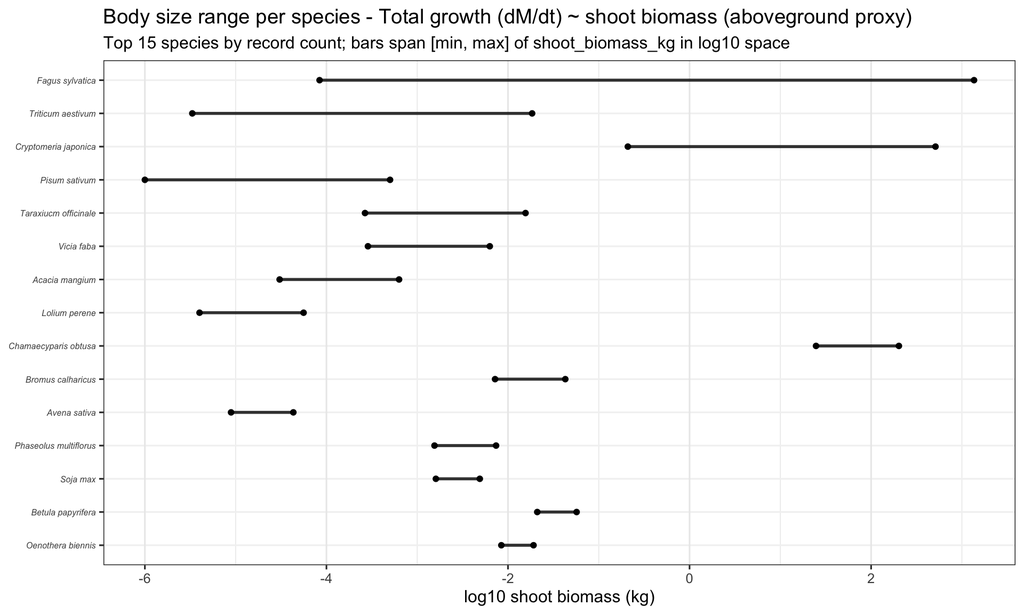

## Scaling slope vs. size range

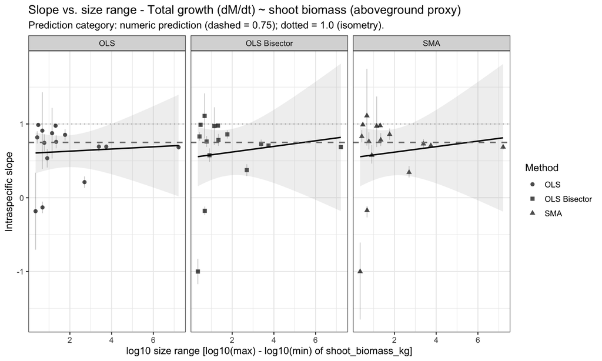

## Slope distributions

Total growth (dM/dt) ~ shoot biomass (aboveground proxy): slope distribution summary statistics

| Method | N | Mean slope | Median slope | Mean 95% CI lo | Mean 95% CI hi |
| --- | --- | --- | --- | --- | --- |
| OLS | 15 | 0.628 | 0.745 | 0.423 | 0.834 |
| SMA | 15 | 0.611 | 0.762 | 0.310 | 0.911 |
| OLS Bisector | 15 | 0.612 | 0.763 | 0.312 | 0.913 |

## 9.4

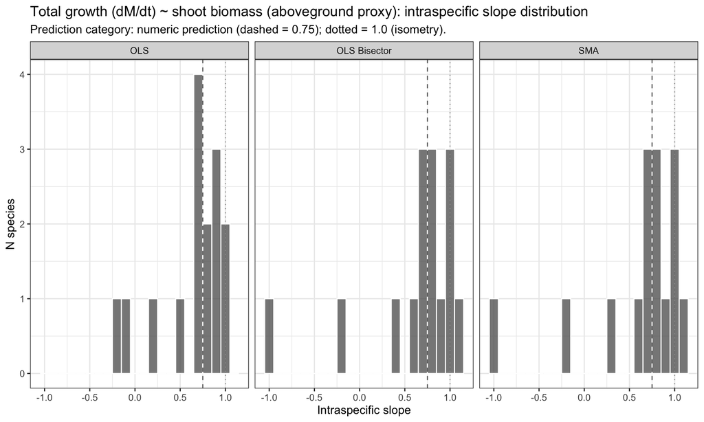

# 10 Total growth (dM/dt) ~ basal stem diameter proxy (total_growth_kgyr ~ basal_diameter_m_proxy)

## 10.1 Summary stats

Total growth (dM/dt) ~ basal stem diameter proxy: summary statistics

| metric | value |
| --- | --- |
| Species qualifying (>=10 records) | 2.000 |
| Median OLS slope | 1.590 |
| Median SMA slope | 1.691 |
| Median OLS Bisector slope | 1.689 |

## 10.2 Per-species slopes table

Total growth (dM/dt) ~ basal stem diameter proxy: per-species OLS, SMA, and OLS Bisector slopes

| Species | Study | N | OLS slope | OLS 95% lo | OLS 95% hi | SMA slope | SMA 95% lo | SMA 95% hi | Bisector slope | Bis 95% lo | Bis 95% hi | R2 | log10 size range |
| --- | --- | --- | --- | --- | --- | --- | --- | --- | --- | --- | --- | --- | --- |
| *Cryptomeria japonica* | Cannell (1982). Page 152 | 55 | 1.763 | 1.587 | 1.940 | 1.876 | 1.708 | 2.061 | 1.874 | 1.756 | 1.992 | 0.884 | 1.353 |
| *Chamaecyparis obtusa* | Cannell (1982). Page 135 | 15 | 1.416 | 1.110 | 1.722 | 1.505 | 1.230 | 1.841 | 1.504 | 1.254 | 1.754 | 0.885 | 0.366 |

## 10.3 Body size range per species

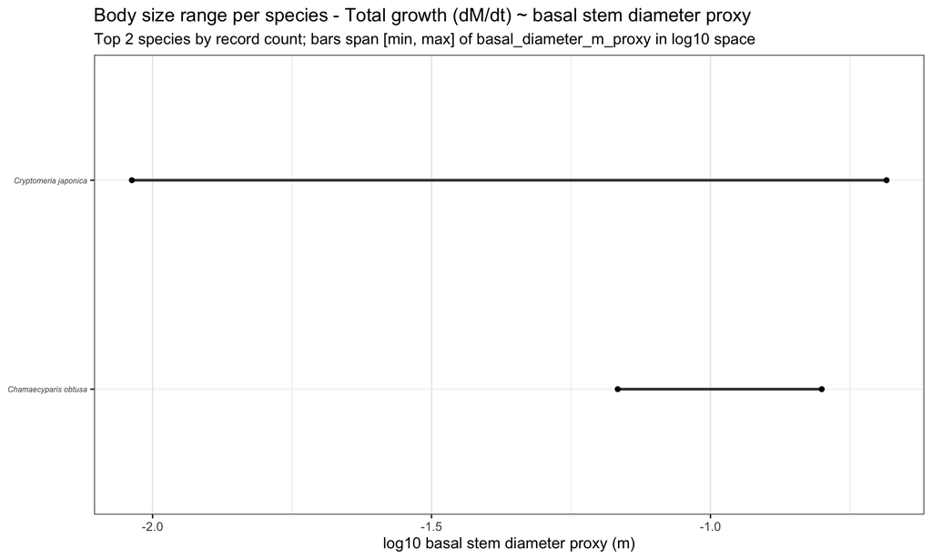

## Scaling slope vs. size range

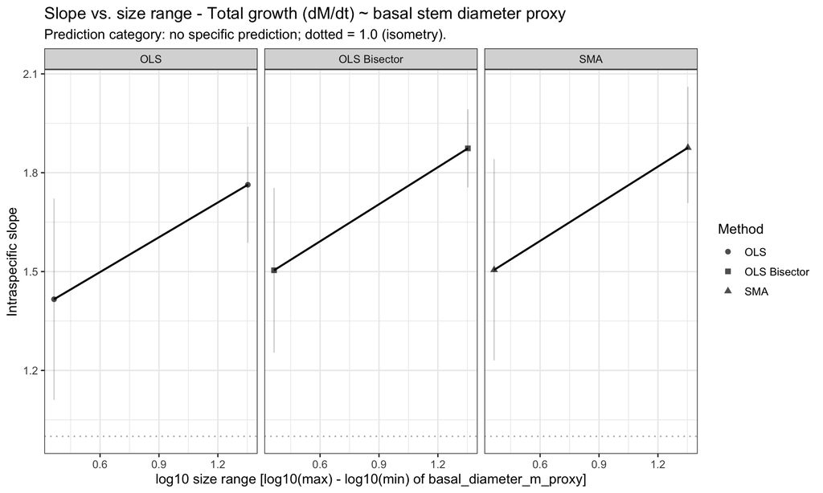

## Slope distributions

Total growth (dM/dt) ~ basal stem diameter proxy: slope distribution summary statistics

| Method | N | Mean slope | Median slope | Mean 95% CI lo | Mean 95% CI hi |
| --- | --- | --- | --- | --- | --- |
| OLS | 2 | 1.590 | 1.590 | -0.618 | 3.797 |
| SMA | 2 | 1.691 | 1.691 | -0.666 | 4.047 |
| OLS Bisector | 2 | 1.689 | 1.689 | -0.661 | 4.039 |

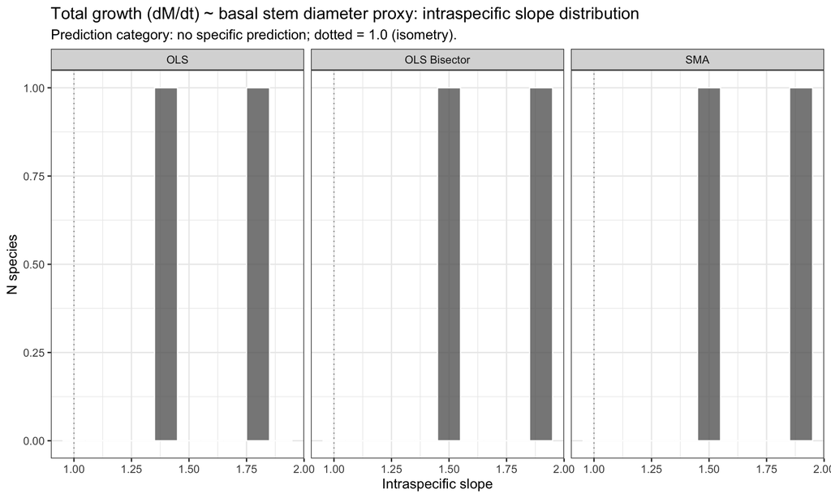

# 11 Cross-combination summary

## 11.1 Median slopes and spread across all 9 relationships

```r
all_res <- bind_rows(lapply(seq_along(combos), function(i) {
  co <- combos[[i]]
  res <- results[[co$id]]
  if (nrow(res) == 0) return(tibble())
  res %>% mutate(combo = co$id, combo_title = co$title, wbe_ref = co$wbe_ref,
                 prediction_category = co$prediction_category)
}))

if (nrow(all_res) == 0) {
  kable(
    data.frame(Note = "No species met thresholds for any combination."),
    caption = "Cross-combination summary"
  )
} else {
  cross_sum <- all_res %>%
    group_by(combo, combo_title) %>%
    summarise(
      n_species = n(),
      prediction_category = prediction_category[1],
      wbe_pred = ifelse(is.finite(wbe_ref[1]), as.character(wbe_ref[1]), "none"),
      med_ols = round(median(ols_slope[is.finite(ols_slope)], na.rm = TRUE), 3),
      iqr_ols = round(IQR(ols_slope[is.finite(ols_slope)], na.rm = TRUE), 3),
      med_sma = round(median(sma_slope[is.finite(sma_slope)], na.rm = TRUE), 3),
      iqr_sma = round(IQR(sma_slope[is.finite(sma_slope)], na.rm = TRUE), 3),
      med_bis = round(median(bis_slope[is.finite(bis_slope)], na.rm = TRUE), 3),
      iqr_bis = round(IQR(bis_slope[is.finite(bis_slope)], na.rm = TRUE), 3),
      med_r2 = round(median(r2[is.finite(r2)], na.rm = TRUE), 3),
      med_range = round(median(log_x_range[is.finite(log_x_range)], na.rm = TRUE), 3),
      .groups = "drop"
    )

  kable(
    cross_sum %>% select(combo, prediction_category, wbe_pred, n_species, med_ols, iqr_ols, med_sma, iqr_sma, med_bis, iqr_bis, med_r2, med_range),
    col.names = c(
      "Combination", "Prediction category", "Predicted exponent", "N species",
      "Median OLS slope", "IQR (OLS)",
      "Median SMA slope", "IQR (SMA)",
      "Median Bisector slope", "IQR (Bisector)",
      "Median R2", "Median log10 range"
    ),
    caption = paste0("Cross-combination summary of intraspecific slopes (>= ", MIN_N, " records/species).")
  )
}
```

Cross-combination summary of intraspecific slopes (>= 10 records/species).

| Combination | Prediction category | Predicted exponent | N species | Median OLS slope | IQR (OLS) | Median SMA slope | IQR (SMA) | Median Bisector slope | IQR (Bisector) | Median R2 | Median log10 range |
| --- | --- | --- | --- | --- | --- | --- | --- | --- | --- | --- | --- |
| leaf_biomass~height | no specific prediction | none | 15 | 1.721 | 0.571 | 2.040 | 0.824 | 1.992 | 0.753 | 0.713 | 0.654 |
| leaf_biomass~root_biomass | no specific prediction | none | 14 | 0.680 | 0.222 | 0.723 | 0.179 | 0.723 | 0.159 | 0.820 | 1.596 |
| leaf_biomass~shoot_biomass | no specific prediction | none | 21 | 0.751 | 0.212 | 0.753 | 0.245 | 0.753 | 0.245 | 0.956 | 1.768 |
| leaf_biomass~stem_biomass | assumption-conditional prediction | 0.75 | 22 | 0.646 | 0.237 | 0.699 | 0.218 | 0.700 | 0.206 | 0.874 | 1.951 |
| leaf_biomass~total_biomass | numeric prediction | 0.75 | 14 | 0.721 | 0.195 | 0.773 | 0.259 | 0.773 | 0.260 | 0.894 | 1.399 |
| leaf_growth~total_biomass | numeric prediction | 0.75 | 7 | 0.699 | 0.233 | 0.818 | 0.378 | 0.820 | 0.377 | 0.921 | 0.914 |
| total_growth~basal_diameter_proxy | no specific prediction | none | 2 | 1.590 | 0.174 | 1.691 | 0.185 | 1.689 | 0.185 | 0.884 | 0.859 |
| total_growth~shoot_biomass | numeric prediction | 0.75 | 15 | 0.745 | 0.253 | 0.762 | 0.284 | 0.763 | 0.283 | 0.936 | 1.146 |
| total_growth~stem_biomass | numeric prediction | 0.75 | 7 | 0.633 | 0.149 | 0.656 | 0.136 | 0.656 | 0.135 | 0.848 | 1.373 |

## 11.2 Slope vs. size range - all 9 combinations

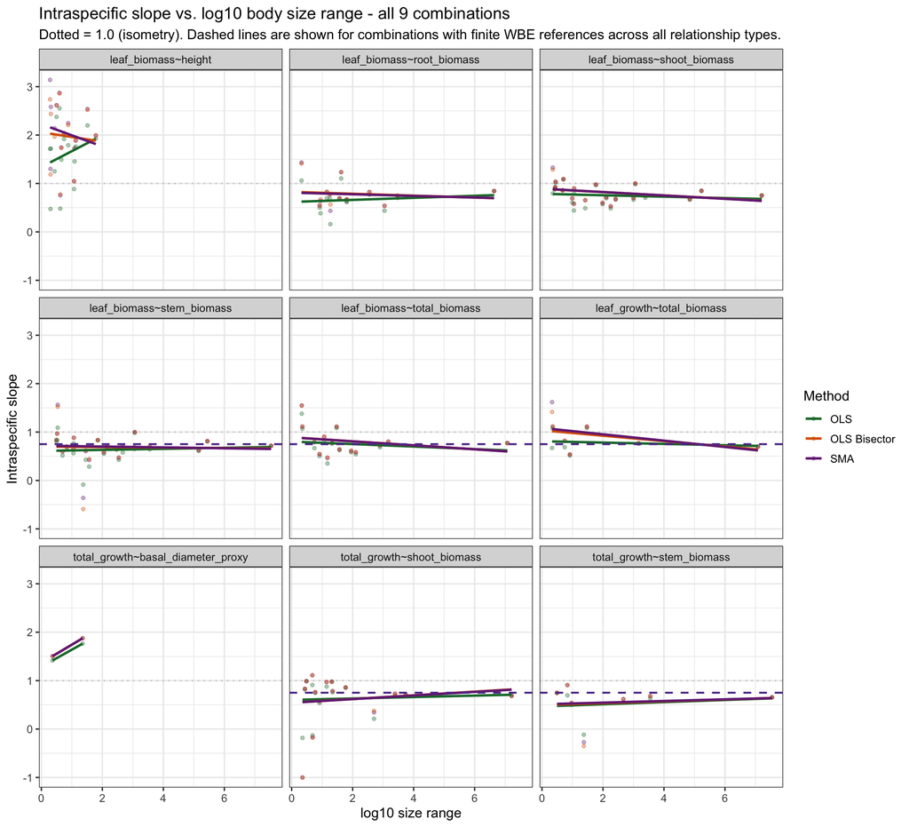

```r
if (nrow(all_res) == 0) {
  ggplot() +
    theme_void() +
    labs(title = "No qualifying species across combinations")
} else {
  long_all <- all_res %>%
    pivot_longer(cols = c(ols_slope, sma_slope, bis_slope), names_to = "method", values_to = "slope") %>%
    mutate(
      method = recode(method,
        ols_slope = "OLS",
        sma_slope = "SMA",
        bis_slope = "OLS Bisector"
      )
    ) %>%
    filter(is.finite(slope), is.finite(log_x_range))

  wbe_lines <- tibble::tibble(
    combo = vapply(combos, `[[`, character(1), "id"),
    wbe_ref = vapply(combos, `[[`, numeric(1), "wbe_ref")
  ) %>% filter(is.finite(wbe_ref))

  p <- ggplot(long_all, aes(x = log_x_range, y = slope, colour = method)) +
    geom_hline(yintercept = 1.00, linetype = "dotted", colour = "grey80", linewidth = 0.6) +
    geom_point(alpha = 0.35, size = 1.2) +
    geom_smooth(method = "lm", se = FALSE, linewidth = 1.0, alpha = 0.9) +
    scale_colour_manual(values = c("OLS" = "#1b7837", "SMA" = "#762a83", "OLS Bisector" = "#d95f02"), name = "Method") +
    facet_wrap(~ combo, ncol = 3) +
    labs(
      x = "log10 size range",
      y = "Intraspecific slope",
      title = paste0("Intraspecific slope vs. log10 body size range - all ", length(combos), " combinations"),
      subtitle = "Dotted = 1.0 (isometry). Dashed lines are shown for combinations with finite WBE references across all relationship types."
    )

  if (nrow(wbe_lines) > 0) {
    p <- p +
      geom_hline(
        data = wbe_lines,
        aes(yintercept = wbe_ref),
        inherit.aes = FALSE,
        linetype = "dashed",
        colour = "#5e3c99",
        linewidth = 0.8
      )
  }

  p
}
```

# 12 Methods

- Data source: Niklas-Enquist biomass dataset at data/raw/niklas_enquist/niklas_enquist_biomass_20040122.csv.
- Cleaning: all non-text columns coerced to numeric; -999 sentinel values replaced with NA.
- Species parsing: only records that resolve to a simple binomial in taxa are retained for per-species regressions.
- Regressions: OLS, SMA, and OLS Bisector on log10-transformed x and y values after filtering to positive x and y.
- Thresholding: species must have at least MIN_N records and non-zero log10 size range for each combination.
- Basal diameter proxy caveat: basal_diameter_m_proxy is derived as d = sqrt(4 * stem_biomass_kg / (pi * rho * height_m)) using rho = 600 kg m^-3; it is a geometric proxy, not a direct measured diameter.
- WBE caveat for proxy predictor: no specific WBE exponent is asserted for dM/dt vs basal_diameter_m_proxy, so WBE reference lines are omitted for that combination.
- Robustness: helpers return informative empty outputs for no-result scenarios; distribution summaries use only finite slopes.